# Answer to Time to Play - Binomial Distribution

First, observe that you are counting “how many” of the $n = 50$ independent orders were made by Amazon Prime Members. This “how many” count is a random variable to be represented by $X$. The probabilty distribution function of $X$ is then
$$P(X = x) = {50 \choose x}(0.62)^{x}(0.38)^{50 - x} \hspace{0.2in} \text{for} \:\: x = 0, 1, 2, \cdots, 50$$

1. To compute the probability that 35 of the 50 orders are from Amazon Prime Members, or $P(X = 35)$:
   $$P(X = 35) = {50 \choose 35}(0.62)^{35}(0.38)^{50 - 35} = 0.06064649 \approx 0.0606$$
   This can also be computed - in fact, you are encouraged to do so - with R:

```r
dbinom(35, 50, 0.62)  #x = 35, n = 50, p = 0.62
```

```
[1] 0.06064649
```

2. Required to compute $P(20 \leq X \leq 40)$. This probability is computed with
   $$\begin{aligned}
   P(20 \leq X \leq 40) = & P(X = 20) + P(X = 21) + \cdots + P(X = 40) \\
   = & {50 \choose 20}(0.62)^{20}(0.38)^{30} + {50 \choose 21}(0.62)^{21}(0.38)^{29} + \cdots + {50 \choose 40}(0.62)^{40}(0.38)^{10} \\
   = & 0.9976026 \\
   \approx & 0.9976
   \end{aligned}$$
   With R,

```r
pbinom(40, 50, 0.62) - pbinom(19, 50, 0.62)  #P(X <= 40) - P(X <= 19)
```

```
[1] 0.9976026
```

3. To compute $P(X \geq 40)$
   $$\begin{aligned}
   P(X \geq 40) = & P(X = 40) + P(X = 41) + \cdots + P(X = 50) \\
   = & {50 \choose 40}(0.62)^{40}(0.38)^{10} + {50 \choose 41}(0.62)^{41}(0.38)^{9} + \cdots + {50 \choose 50}(0.62)^{50}(0.38)^{0} \\
   = & 0.005098307\\
   \approx & 0.0051
   \end{aligned}$$
   This can be computed with the `sum` and `dbinom` commands below:

```r
sum(dbinom(40:50, 50, 0.62))
```

```
[1] 0.005098307
```

Alternatively you can use the `pbinom` function to compute this probability.

```r
1 - pbinom(39, 50, 0.62)  #1 - P(X <= 39)
```

```
[1] 0.005098307
```

4. To visualize the distribution of $X$, the number of orders of the 50 made by Amazon Prime Members use then modify the R code that accompanies Example 1:

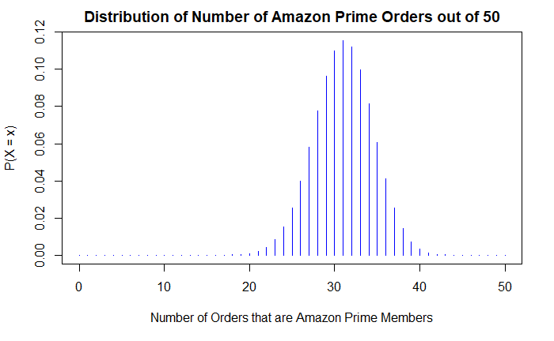

```r
noamazonprimembers = 0:50
probapm = dbinom(noamazonprimembers, 50, 0.62)
plot(noamazonprimembers, probapm, xlab="Number of Orders that are Amazon Prime Members", ylab="P(X = x)", main="Distribution of Number of Amazon Prime Orders out of 50", type="h", col='blue')
```

The distribution is slightly *left-skewed*, with higher values of $X$ being more likely than small counts.

5. The expected value/mean and standard deviation of the random variable that counts the number, out of 50 orders, that were made by Amazon Prime Members are computed to be
   $$\mu_{X} = E(X) = 50*(0.62) = 31 \: \text{rrders are AP Members} \hspace{0.25in} {\rm and} \hspace{0.25in} \sigma_{X} = SD(X) = \sqrt{31*(0.38)} = 3.43 \; \text{orders are AP Members}$$
6. From the result in part (e)
   $$(\mu_{X} - \sigma_{X}, \mu_{X} + \sigma_{X}) \rightarrow *31 - 3.43, 31 + 3.43) = (27.57, 34.43)$$
   Computing $P(27.57< X < 34.43) = P(28 \leq X \leq 34) = 0.6922672 \approx 0.6923$, which is completed with R below:

```r
pbinom(34, 50, 0.62) - pbinom(27, 50, 0.62)  #P(X <= 34) - P(X <= 27)
```

```
[1] 0.6922672
```

Approximately 69.23% of the time, the number of 50 Amazon orders that are from Amazon Prime Members is somewhere between 28 and 34, inclusive.